# Assignment 1

Jiyun Won

2/22/2022

## Download required Packages

```r
if (! requireNamespace("biocManager", quietly = TRUE)){
  install.packages("BiocManager", repos = "http://cran.us.r-project.org")
}
```

```
##
##  /var/folders/_c/59gypyts1hn8xzqlpwyxvlw80000gn/T//RtmpNiBUbL/downloaded_packages
```

```r
if (! requireNamespace("GEOmetadb", quietly = TRUE)){
  BiocManager::install("GEOmetadb")
  }
```

```
## Setting options('download.file.method.GEOquery'='auto')
```

```
## Setting options('GEOquery.inmemory.gpl'=FALSE)
```

```r
if (! requireNamespace("GEOquery", quietly = TRUE)){
  BiocManager::install("GEOquery")
}
if (! requireNamespace("edgeR", quietly = TRUE)){
  BiocManager::install("edgeR")
}
if (! requireNamespace("biomaRt", quietly = TRUE)){
  BiocManager::install("biomaRt")
}
```

Libraries

```r
library(BiocManager)
library(GEOmetadb)
library(GEOquery)
library(edgeR)
library(biomaRt)
```

## Download dataset : GEOmetadb

To access the required gene dataset, download the GEOmeta file.

```r
if (!file.exists("GSE84054_Rawcount_12patientER.txt.gz")){
  GSE84054 <- GEOquery::getGEOSuppFiles('GSE84054')
}
fnames = rownames(GSE84054)
```

extract rawcount data as a data frame from fnames

```r
exp <- read.delim(fnames[2], header=TRUE, check.names = FALSE)
dim(exp)
```

```
## [1] 57268    25
```

```r
head(exp)
```

```
##                   RHB037 RHB038 RHB041 RHB049 RHB050 RHB052 RHB053 RHB350
## 1 ENSG00000000003   2561   2141   1186    233    742    879   2946    745
## 2 ENSG00000000005      0      3     12      9      0      1      1      1
## 3 ENSG00000000419   1170   1299   1560    210    901    737    990    508
## 4 ENSG00000000457    387    408    199     83    338    242    230    118
## 5 ENSG00000000460    217    168    121     41    189     94     94     67
## 6 ENSG00000000938     45    134     61    132     72     77     79     28
##   RHB351 RHB353 RHB354 RHB355 RHB031 RHB032 RHB035 RHB043 RHB044 RHB046 RHB047
## 1    273    506    841   1245   1845   1011   3135   1570    954   2087   4262
## 2      8      0     71      2      0      0      0      0      0      0      0
## 3    332    261    312    313   2119   1236   2079   1763   2515   2522   2064
## 4     65    242    147    386    210    494    260    111    241    191    287
## 5     34     90     55    124    248    152     80    230    117    210     73
## 6     66     27     45     32      6     28      0     30      0      0      0
##   RHB344 RHB345 RHB347 RHB348 RHB349
## 1    860   2118    274   1038   1660
## 2      0      0      0      0      0
## 3   1780   2019    522   1012    690
## 4    249    207    270    164    751
## 5    147     67     71     77     54
## 6      0      0      0      0      0
```

### Cleaning the data

According to the GSE84054 NCBI page, the first 12 samples provided are patients with primary tumour and the last 12 samples are patients with Sphere breast cancer. Create a data frame that indicates the sample type (Primary or Sphere).

```r
dt_type <- data.frame("Type"=1:24)
for (type1 in 1:12){
  dt_type$Type[type1] = "Primary Tumour"
}
for (type2 in 13:24){
  dt_type$Type[type2] = "Sphere"
}
rownames(dt_type) <- colnames(exp)[2:25]

head(dt_type) # Primary Tumour
```

```
##                  Type
## RHB037 Primary Tumour
## RHB038 Primary Tumour
## RHB041 Primary Tumour
## RHB049 Primary Tumour
## RHB050 Primary Tumour
## RHB052 Primary Tumour
```

```r
tail(dt_type) # Sphere
```

```
##          Type
## RHB047 Sphere
## RHB344 Sphere
## RHB345 Sphere
## RHB347 Sphere
## RHB348 Sphere
## RHB349 Sphere
```

Use edgeR package to filter unnecessary data that does not have meaningful contribution to the research.

```r
# filter data
cpms = edgeR::cpm(exp[, 2:25])
keep = rowSums(cpms > 1) >= 3 # Dataset of 3 samples per group
filtered_exp <- exp[keep,]
# check filtered data
head(filtered_exp)
```

```
##                   RHB037 RHB038 RHB041 RHB049 RHB050 RHB052 RHB053 RHB350
## 1 ENSG00000000003   2561   2141   1186    233    742    879   2946    745
## 3 ENSG00000000419   1170   1299   1560    210    901    737    990    508
## 4 ENSG00000000457    387    408    199     83    338    242    230    118
## 5 ENSG00000000460    217    168    121     41    189     94     94     67
## 6 ENSG00000000938     45    134     61    132     72     77     79     28
## 7 ENSG00000000971     76    565    467   1348    846    496   1940    252
##   RHB351 RHB353 RHB354 RHB355 RHB031 RHB032 RHB035 RHB043 RHB044 RHB046 RHB047
## 1    273    506    841   1245   1845   1011   3135   1570    954   2087   4262
## 3    332    261    312    313   2119   1236   2079   1763   2515   2522   2064
## 4     65    242    147    386    210    494    260    111    241    191    287
## 5     34     90     55    124    248    152     80    230    117    210     73
## 6     66     27     45     32      6     28      0     30      0      0      0
## 7   1430    598   1385   1344      2     11     16      0      0      0     86
##   RHB344 RHB345 RHB347 RHB348 RHB349
## 1    860   2118    274   1038   1660
## 3   1780   2019    522   1012    690
## 4    249    207    270    164    751
## 5    147     67     71     77     54
## 6      0      0      0      0      0
## 7      1      1      0    283      0
```

```r
dim(filtered_exp) # 19873
```

```
## [1] 19873    25
```

### Mapping gene (assign to proper HUGO symbol)

The dataset consist of ensemblID to represent the genes so we map these IDs to HUGO gene symbols.

```r
mart <- biomaRt::useMart("ensembl", dataset = "hsapiens_gene_ensembl")
```

```
## Ensembl site unresponsive, trying asia mirror
```

```r
map_exp <- biomaRt::getBM(filters = "ensembl_gene_id", attributes = c("hgnc_symbol", "ensembl_gene_id"), values = filtered_exp[1], mart = mart)
head(map_exp) # new mapped dataset top 6 rows
```

```
##   hgnc_symbol ensembl_gene_id
## 1      TSPAN6 ENSG00000000003
## 2        DPM1 ENSG00000000419
## 3       SCYL3 ENSG00000000457
## 4    C1orf112 ENSG00000000460
## 5         FGR ENSG00000000938
## 6         CFH ENSG00000000971
```

```r
nrow(map_exp) # 19145 : some IDs not found or more than one ids mapped to same gene
```

```
## [1] 19145
```

96% of the genes are mapped to proper HUGO gene symbols so the remaining missing IDs will not be an issue here. No update required.

### Clean new mapped dataset

Check if no empty values

```r
map_exp <- map_exp[!(map_exp %in% c(""))]
```

Check for duplicates

```r
sum(duplicated(map_exp$ensembl_gene_id))
```

```
## [1] 1
```

```r
sum(! (filtered_exp[1]) %in% map_exp$ensembl_gene_id)
```

```
## [1] 1
```

```r
dup <- map_exp$ensembl_gene_id[duplicated(map_exp$ensembl_gene_id)]
map_exp[map_exp$ensembl_gene_id %in% dup, ]
```

```
##           hgnc_symbol ensembl_gene_id
## 17810 SUGT1P4-STRA6LP ENSG00000254876
## 17811         STRA6LP ENSG00000254876
```

The two HUGO symbols indicated as duplicates are the same gene according to the ensembl gene portal so no change is required.

```r
copy_filter <- filtered_exp
copy_filter <- merge(map_exp, copy_filter, by.x = 2, by.y = 1, all.y = TRUE)
head(copy_filter)
```

```
##   ensembl_gene_id hgnc_symbol RHB037 RHB038 RHB041 RHB049 RHB050 RHB052 RHB053
## 1 ENSG00000000003      TSPAN6   2561   2141   1186    233    742    879   2946
## 2 ENSG00000000419        DPM1   1170   1299   1560    210    901    737    990
## 3 ENSG00000000457       SCYL3    387    408    199     83    338    242    230
## 4 ENSG00000000460    C1orf112    217    168    121     41    189     94     94
## 5 ENSG00000000938         FGR     45    134     61    132     72     77     79
## 6 ENSG00000000971         CFH     76    565    467   1348    846    496   1940
##   RHB350 RHB351 RHB353 RHB354 RHB355 RHB031 RHB032 RHB035 RHB043 RHB044 RHB046
## 1    745    273    506    841   1245   1845   1011   3135   1570    954   2087
## 2    508    332    261    312    313   2119   1236   2079   1763   2515   2522
## 3    118     65    242    147    386    210    494    260    111    241    191
## 4     67     34     90     55    124    248    152     80    230    117    210
## 5     28     66     27     45     32      6     28      0     30      0      0
## 6    252   1430    598   1385   1344      2     11     16      0      0      0
##   RHB047 RHB344 RHB345 RHB347 RHB348 RHB349
## 1   4262    860   2118    274   1038   1660
## 2   2064   1780   2019    522   1012    690
## 3    287    249    207    270    164    751
## 4     73    147     67     71     77     54
## 5      0      0      0      0      0      0
## 6     86      1      1      0    283      0
```

```r
length(copy_filter$ensembl_gene_id[which(is.na(copy_filter$hgnc_symbol))]) # no duplicates
```

```
## [1] 729
```

save mapped dataset into new dataset filtered2exp

```r
filtered2exp <- map_exp$hgnc_symbol
names(filtered2exp) <- map_exp$ensembl_gene_id
head(filtered2exp)
```

```
## ENSG00000000003 ENSG00000000419 ENSG00000000457 ENSG00000000460 ENSG00000000938
##        "TSPAN6"          "DPM1"         "SCYL3"      "C1orf112"           "FGR"
## ENSG00000000971
##           "CFH"
```

### Normalization

Before normalization, examine different visualizations of dataset distribution.

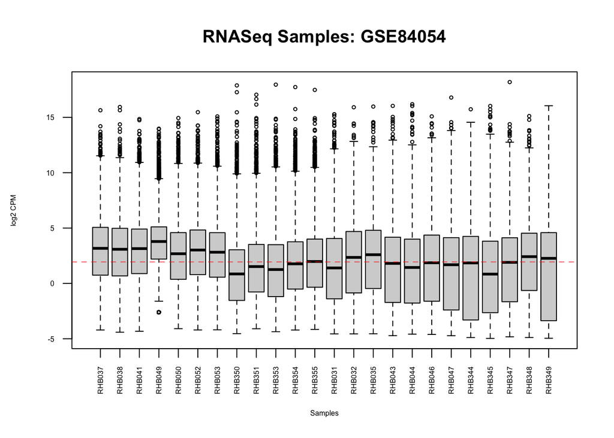

```r
data2plot <- log2(edgeR::cpm(copy_filter[, 3:26]))
boxplot(data2plot, xlab = "Samples", ylab = "log2 CPM", las = 2, cex = 0.5,
        cex.lab = 0.5, cex.axis = 0.5, main = "RNASeq Samples: GSE84054")
abline(h = median(apply(data2plot, 2, median)), col = "red", lwd = 0.6, lty = "dashed")
```

Density Plot (before): higher peak on the left side

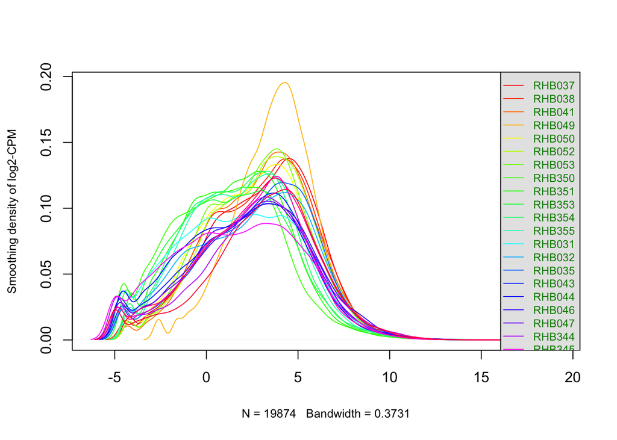

```r
counts_density <- apply(log2(edgeR::cpm(copy_filter[,3:26])), 2, density)
                             xlim <- 0
                             ylim <- 0
                             for (i in 1:length(counts_density)){
                               xlim <- range(c(xlim, counts_density[[i]]$x));
                               ylim <- range(c(ylim, counts_density[[i]]$y))
                             }
                             cols <- rainbow(length(counts_density))
                             ltys <- rep(1, length(counts_density))
                             plot(counts_density[[i]], xlim = xlim,
                                  ylim = ylim, type = "n",
                                  ylab = "Smoothing density of log2-CPM", main = "", cex.lab = 0.8)
                             for(i in 1:length(counts_density)){
                               lines(counts_density[[i]], col=cols[i], lty=ltys[i])
                             }
                             legend("topright", colnames(data2plot), col=cols, lty=ltys,
                                    cex=0.75, border="blue", text.col = "green4",
                                    merge = TRUE, bg = "gray90")
```

Normalization on filtered_exp data Use TMM normalization for RNA seq data : effective in estimating RNA production levels from RNA-seq data.

```r
mat <- as.matrix(copy_filter[,3:26])
rownames(mat) <- copy_filter$ensembl_gene_id
d <- edgeR::DGEList(counts = mat, group = dt_type$Type)
d <- edgeR::calcNormFactors(d)
normalized_counts <- edgeR::cpm(d)
rownames(normalized_counts) <- copy_filter$hgnc_symbol
nrow(normalized_counts)
```

```
## [1] 19874
```

```r
head(normalized_counts)
```

```
##             RHB037    RHB038    RHB041     RHB049    RHB050    RHB052
## TSPAN6   79.762097 63.325115 37.691139  19.295797 34.674826 33.356690
## DPM1     36.439537 38.420983 49.576878  17.391062 42.105146 27.968009
## SCYL3    12.053077 12.067560  6.324230   6.873610 15.795271  9.183525
## C1orf112  6.758444  4.968995  3.845386   3.395398  8.832267  3.567155
## FGR       1.401521  3.963365  1.938583  10.931525  3.364673  2.922031
## CFH       2.367013 16.711205 14.841283 111.634054 39.534910 18.822432
##              RHB053    RHB350     RHB351    RHB353     RHB354    RHB355
## TSPAN6   132.865318 75.410123  28.017088 42.143016  65.099495 85.324514
## DPM1      44.649241 51.420594  34.072063 21.737801  24.151061 21.451063
## SCYL3     10.373056 11.944154   6.670735 20.155356  11.378865 26.454026
## C1orf112   4.239423  6.781850   3.489308  7.495793   4.257399  8.498185
## FGR        3.562919  2.834206   6.773362  2.248738   3.483326  2.193080
## CFH       87.494473 25.507854 146.756175 49.805383 107.209037 92.109355
##               RHB031     RHB032      RHB035    RHB043     RHB044     RHB046
## TSPAN6    94.7436563 34.5777158 101.6942883 65.003158  50.780217  86.536002
## DPM1     108.8139879 42.2730532  67.4393701 72.993992 133.870277 104.572974
## SCYL3     10.7838308 16.8955407   8.4339761  4.595765  12.828126   7.919682
## C1orf112  12.7351907  5.1986279   2.5950696  9.522756   6.227762   8.707504
## FGR        0.3081095  0.9576420   0.0000000  1.242099   0.000000   0.000000
## CFH        0.1027032  0.3762165   0.5190139  0.000000   0.000000   0.000000
##              RHB047      RHB344       RHB345    RHB347    RHB348    RHB349
## TSPAN6   185.486509 30.65508642 101.41248943 10.489721 30.505676 45.284259
## DPM1      89.827347 63.44889979  96.67224559 19.984067 29.741565 18.822975
## SCYL3     12.490527  8.87571688   9.91141894 10.336586  4.819779 20.487035
## C1orf112   3.177033  5.23988105   3.20804381  2.718139  2.262945  1.473102
## FGR        0.000000  0.00000000   0.00000000  0.000000  0.000000  0.000000
## CFH        3.742806  0.03564545   0.04788125  0.000000  8.317058  0.000000
```

Now, do the exact investigation by plotting boxplot and density graph after normalization.

Boxplot (after): Median line lies very close to all samples’ median value

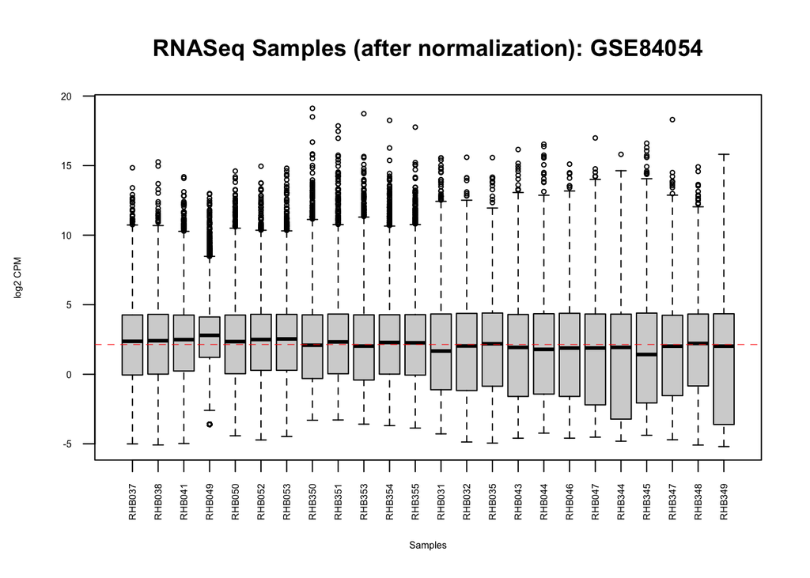

```r
data2plot <- log2(normalized_counts)
boxplot(data2plot, xlab = "Samples", ylab = "log2 CPM", las = 2, cex = 0.5,
        cex.lab = 0.5, cex.axis = 0.5, main = "RNASeq Samples (after normalization): GSE84054")
abline(h = median(apply(data2plot, 2, median)), col = "red", lwd = 0.6, lty = "dashed")
```

Density Plot (after): No big change

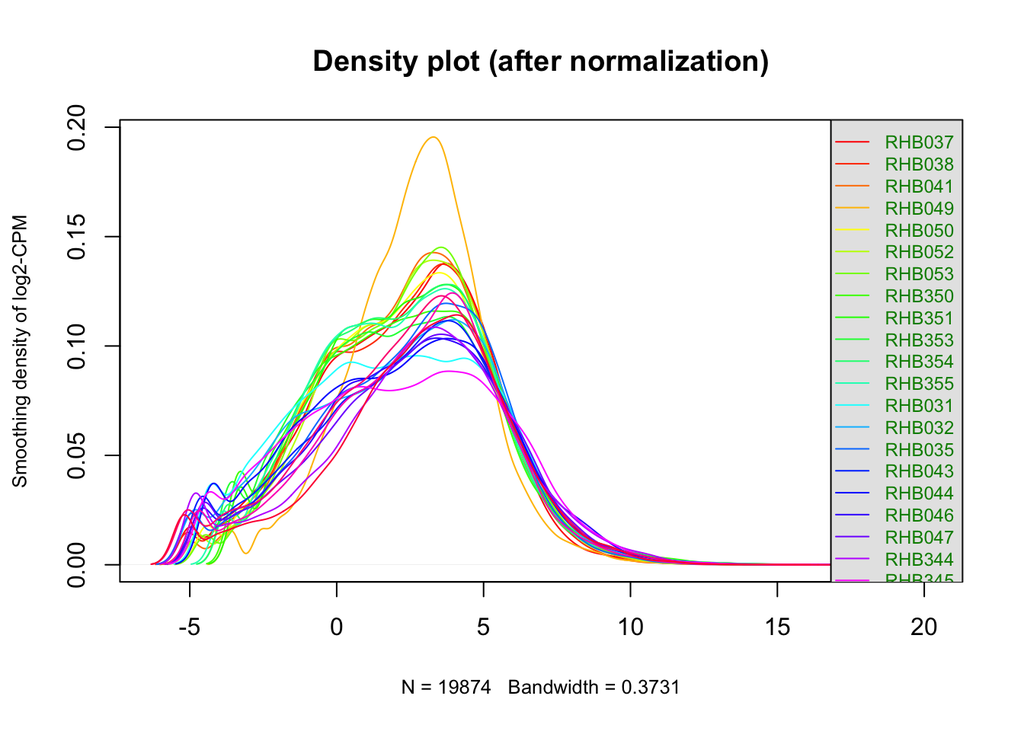

```r
counts_density <- apply(log2(normalized_counts), 2, density)
                             xlim <- 0
                             ylim <- 0
                             for (i in 1:length(counts_density)){
                               xlim <- range(c(xlim, counts_density[[i]]$x));
                               ylim <- range(c(ylim, counts_density[[i]]$y))
                             }
                             cols <- rainbow(length(counts_density))
                             ltys <- rep(1, length(counts_density))
                             plot(counts_density[[i]], xlim = xlim,
                                  ylim = ylim, type = "n",
                                  ylab = "Smoothing density of log2-CPM", main = "Density plot (after normalization)", cex.lab = 0.8)
                             for(i in 1:length(counts_density)){
                               lines(counts_density[[i]], col=cols[i], lty=ltys[i])
                             }
                             legend("topright", colnames(data2plot), col=cols, lty=ltys,
                                    cex=0.75, border="blue", text.col = "green4",
                                    merge = TRUE, bg = "gray90")
```

MDS Plot (after):

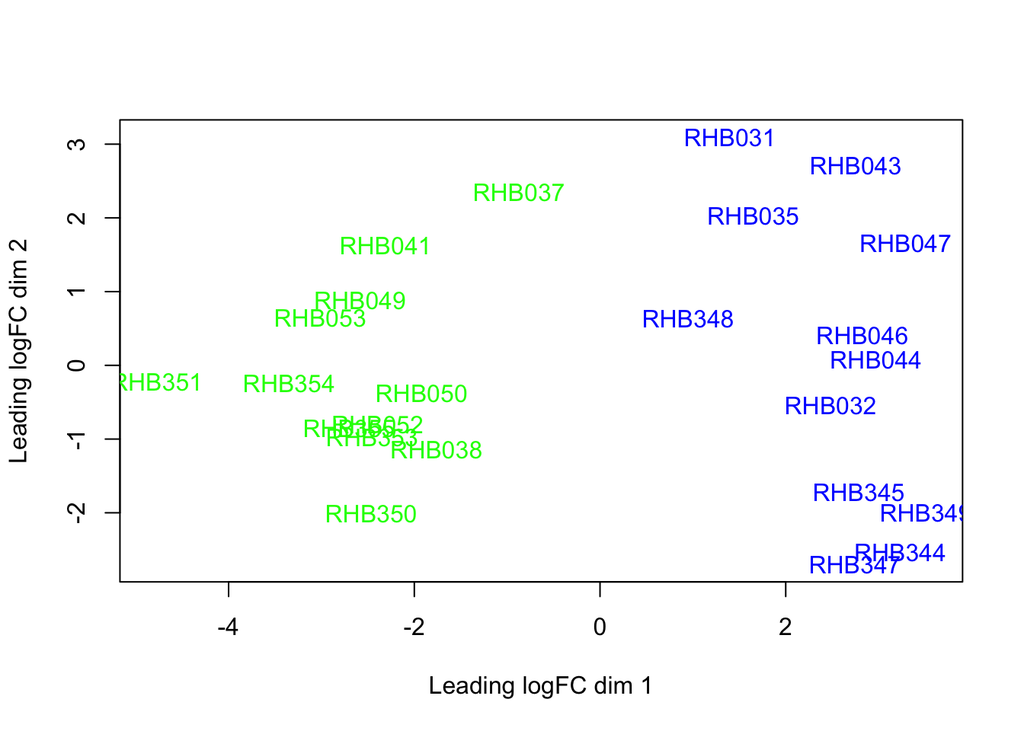

```r
plotMDS(d, labels = rownames(dt_type), col = c("green","blue", "red")[factor(dt_type$Type)])
```

# Final Coverage

```r
nrow(normalized_counts) / nrow(exp)
```

```
## [1] 0.347035
```

# Final dataset

Normalization and cleaning of the dataset complete.

```r
final_data <- as.data.frame(normalized_counts)
head(final_data)
```

```
##             RHB037    RHB038    RHB041     RHB049    RHB050    RHB052
## TSPAN6   79.762097 63.325115 37.691139  19.295797 34.674826 33.356690
## DPM1     36.439537 38.420983 49.576878  17.391062 42.105146 27.968009
## SCYL3    12.053077 12.067560  6.324230   6.873610 15.795271  9.183525
## C1orf112  6.758444  4.968995  3.845386   3.395398  8.832267  3.567155
## FGR       1.401521  3.963365  1.938583  10.931525  3.364673  2.922031
## CFH       2.367013 16.711205 14.841283 111.634054 39.534910 18.822432
##              RHB053    RHB350     RHB351    RHB353     RHB354    RHB355
## TSPAN6   132.865318 75.410123  28.017088 42.143016  65.099495 85.324514
## DPM1      44.649241 51.420594  34.072063 21.737801  24.151061 21.451063
## SCYL3     10.373056 11.944154   6.670735 20.155356  11.378865 26.454026
## C1orf112   4.239423  6.781850   3.489308  7.495793   4.257399  8.498185
## FGR        3.562919  2.834206   6.773362  2.248738   3.483326  2.193080
## CFH       87.494473 25.507854 146.756175 49.805383 107.209037 92.109355
##               RHB031     RHB032      RHB035    RHB043     RHB044     RHB046
## TSPAN6    94.7436563 34.5777158 101.6942883 65.003158  50.780217  86.536002
## DPM1     108.8139879 42.2730532  67.4393701 72.993992 133.870277 104.572974
## SCYL3     10.7838308 16.8955407   8.4339761  4.595765  12.828126   7.919682
## C1orf112  12.7351907  5.1986279   2.5950696  9.522756   6.227762   8.707504
## FGR        0.3081095  0.9576420   0.0000000  1.242099   0.000000   0.000000
## CFH        0.1027032  0.3762165   0.5190139  0.000000   0.000000   0.000000
##              RHB047      RHB344       RHB345    RHB347    RHB348    RHB349
## TSPAN6   185.486509 30.65508642 101.41248943 10.489721 30.505676 45.284259
## DPM1      89.827347 63.44889979  96.67224559 19.984067 29.741565 18.822975
## SCYL3     12.490527  8.87571688   9.91141894 10.336586  4.819779 20.487035
## C1orf112   3.177033  5.23988105   3.20804381  2.718139  2.262945  1.473102
## FGR        0.000000  0.00000000   0.00000000  0.000000  0.000000  0.000000
## CFH        3.742806  0.03564545   0.04788125  0.000000  8.317058  0.000000
```

# Interpret and Document

### What are the control and test conditions of the dataset?

The control condition was the primary tumour samples. The test condition consists of the sphere tumours.

### Why is the dataset of interest to you?

The dataset was interesting as I am interested in investigating cancer diagnostic research and this research suggested possible diagnostic biomarker that can contribute in detecting breast cancer.

### Were there expression values that were not unique for specific genes? How did you handle these?

There were duplicate genes but the numbers were small enough to not exclude them since it did not hve significant impact on the data process.

### Were there expression values that could not be mapped to current HUGO symbols?

Yes, but the total mapped symbols were more than 96% of the orginal dataset so it was disregarded.

### How did you handle replicates?

The ncbi GEO page indicated that 12 out of 24 replicates were primary tumour and other 12 were sphere, so I handled them by sorting them into two groups.

### What is the final coverage of your dataset?

The final coverage of the data set is 34.70%

# References

Isserlin, Ruth. (2022, February 13). BCB420: Lecture 4:Exploring the data and basics of Normalization. Isserlin, Ruth. (2022, February 15). BCB420: Lecture 5:Data exploration and Identifier mapping.